# Getting Started with dashboardr

This vignette walks you through building your first interactive dashboard with dashboardr. By the end, you’ll understand the core concepts and have a working dashboard you can customize.

## What is dashboardr?

dashboardr lets you build interactive HTML dashboards from R using a simple, composable grammar. Think of it like building with Lego blocks:

- **No web development needed**: just R code
- **Interactive charts** powered by Highcharts
- **Beautiful themes** from Bootswatch
- **Flexible layouts** with tabs, pages, and navigation

## Installation

Install dashboardr from GitHub:

```r
devtools::install_github("favstats/dashboardr")
```

## What We’ll Build

In this tutorial, we’ll create a dashboard exploring the General Social Survey (GSS), a long-running survey of American attitudes and demographics. We’ll build charts showing education levels, happiness, and how they relate to each other.

First, let’s load the packages and prepare our data:

```r
library(dashboardr)
library(dplyr)
library(gssr)
# Load GSS data and select relevant variables
data(gss_all)
gss <- gss_all %>%
  select(year, age, sex, race, degree, happy, polviews) %>%
  filter(year >= 2010, !is.na(age), !is.na(sex), !is.na(race), !is.na(degree))
```

We now have a dataset with about 22,000 respondents from 2010 onwards, with variables for demographics (age, sex, race, education) and attitudes (happiness, political views).

## The Three Layers

Just as ggplot2 builds plots from layers (data, aesthetics, geoms), dashboardr builds dashboards from three layers:

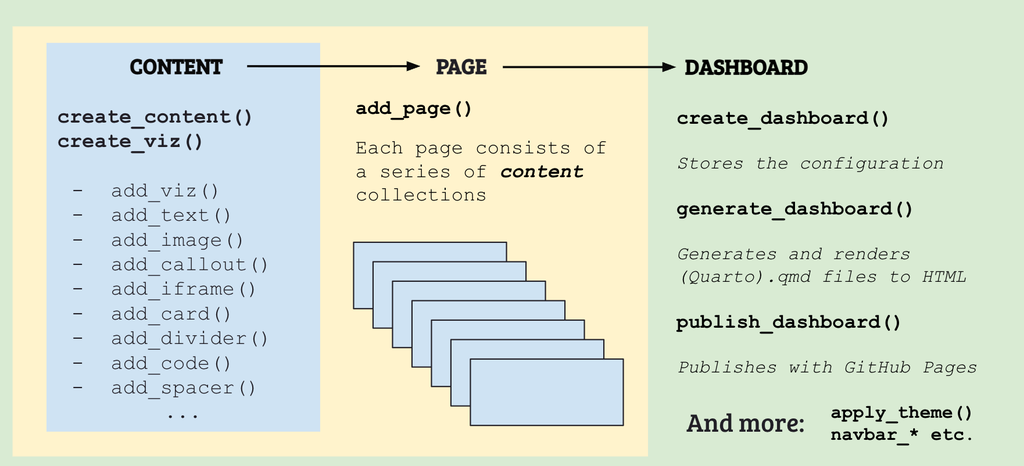

dashboardr workflow: Content flows to Page flows to Dashboard

| Layer | Purpose | Key Functions |
| --- | --- | --- |
| **Content** | What to show (charts, text) | `create_content()`, `add_viz()`, `add_text()` |
| **Page** | Where content lives | `create_page()`, `add_content()` |
| **Dashboard** | Final output + config | `create_dashboard()`, `add_pages()` |

Each layer flows into the next using pipes (`%>%`), making your code readable and modular.

## Layer 1: Content

Content collections hold your visualizations and text. You create one with `create_content()`, passing the data and a default chart type:

```r
demographics <- create_content(data = gss, type = "bar") %>%
  add_viz(x_var = "degree", title = "Education")

print(demographics)
```

```
#> -- Content Collection ----------------------------------------------------------
#> 1 items | v data: 21788 rows x 7 cols
#>
#> * [Viz] Education (bar) x=degree
```

Here `create_content()` sets up a container with the GSS data and says “make bar charts by default.” Then `add_viz()` adds a bar chart of the `degree` variable. The print output shows what’s inside: one visualization ready to go.

Use `preview()` to see the actual chart:

```r
demographics %>% preview()
```

Preview

Education

[interactive chart not shown]

You can keep adding to content collections. Use `tabgroup` to organize charts into tabs:

```r
demographics <- create_content(data = gss, type = "bar") %>%
  add_viz(x_var = "degree", title = "Education", tabgroup = "demographics") %>%
  add_viz(x_var = "race", title = "Race", tabgroup = "demographics") %>%
  add_viz(x_var = "happy", title = "Happiness", tabgroup = "attitudes")

demographics %>% preview()
```

Preview

Education

[interactive chart not shown]

Race

[interactive chart not shown]

Happiness

[interactive chart not shown]

## Layer 2: Pages

Pages organize content and define your dashboard’s navigation. Each page becomes a separate HTML file.

A simple landing page with just text:

```r
home <- create_page("Home", is_landing_page = TRUE) %>%
  add_text("# Welcome!", "", "Explore the General Social Survey data.")

home %>% preview()
```

Preview

Welcome!

Explore the General Social Survey data.

The `is_landing_page = TRUE` makes this the default page when someone opens your dashboard.

Now an analysis page that uses our content from Layer 1:

```r
analysis <- create_page("Analysis", data = gss) %>%
  add_content(demographics)

print(analysis)
```

```
#> -- Page: Analysis -----------------------------------------------
#> v data: 21788 rows x 7 cols
#> 3 items
#>
#> > [Tab] demographics (2 vizs)
#>   * [Viz] Education (bar) x=degree
#>   * [Viz] Race (bar) x=race
#> > [Tab] attitudes (1 viz)
#>   * [Viz] Happiness (bar) x=happy
```

The `add_content()` function connects layers: it takes the content collection you built earlier and attaches it to the page. The page’s `data` argument provides the dataset for any visualizations that need it.

```r
analysis %>% preview()
```

Preview

Education

[interactive chart not shown]

Race

[interactive chart not shown]

Happiness

[interactive chart not shown]

You can also add visualizations directly to pages without creating a separate content collection first:

```r
quick_page <- create_page("Quick", data = gss, type = "bar") %>%
  add_text("## Quick Analysis") %>%
  add_viz(x_var = "happy", title = "Happiness Levels")

quick_page %>% preview()
```

Preview

Quick Analysis

Happiness Levels

[interactive chart not shown]

## Layer 3: Dashboard

The dashboard brings pages together and configures the final output. You specify where to save files, pick a theme, and add your pages:

```r
my_dashboard <- create_dashboard(
  title = "GSS Explorer",
  output_dir = "my_dashboard",
  theme = "flatly"
) %>%
  add_pages(home, analysis)
```

```
#> Output directory already exists: /Users/favstats/Dropbox/postdoc/my_dashboard
#> Files may be overwritten when generate_dashboard() is called.
```

```r
my_dashboard
```

Dashboard Preview: GSS Explorer

Welcome!

Explore the General Social Survey data.

Pages appear in the navbar in the order you add them.

To generate the final HTML dashboard:

```r
my_dashboard %>%
  generate_dashboard(render = TRUE, open = "browser")
```

This creates Quarto files, renders them to HTML, and opens the result in your browser.

You can also preview dashboards without generating everything with Quarto:

```r
my_dashboard %>% preview()
```

Dashboard Preview: GSS Explorer

Welcome!

Explore the General Social Survey data.

## Complete Example

Here’s everything together, from data to published dashboard:

```r
library(dashboardr)
library(dplyr)
library(gssr)

# Prepare data
data(gss_all)
gss <- gss_all %>%
  select(year, age, sex, race, degree, happy, polviews) %>%
  filter(year >= 2010, !is.na(age), !is.na(sex), !is.na(race), !is.na(degree))

# LAYER 1: Build content collections
demographics <- create_content(type = "bar") %>%
  add_viz(x_var = "degree", title = "Education", tabgroup = "overview") %>%
  add_viz(x_var = "race", title = "Race", tabgroup = "overview") %>%
  add_viz(x_var = "sex", title = "Gender", tabgroup = "overview")

cross_tabs <- create_content(type = "stackedbar") %>%
  add_viz(x_var = "degree", stack_var = "happy",
          title = "Happiness by Education", tabgroup = "analysis",
          stacked_type = "percent") %>%
  add_viz(x_var = "polviews", stack_var = "happy",
          title = "Happiness by Politics", tabgroup = "analysis",
          stacked_type = "percent")

# LAYER 2: Create pages
home <- create_page("Home", is_landing_page = TRUE) %>%
  add_text("# GSS Explorer", "",
           "Explore trends in American society using the General Social Survey.",
           "", "Navigate using the tabs above.")

analysis <- create_page("Analysis", data = gss, icon = "ph:chart-bar") %>%
  add_content(demographics) %>%
  add_content(cross_tabs)

about <- create_page("About", navbar_align = "right", icon = "ph:info") %>%
  add_text("## About This Dashboard", "",
           "Created with dashboardr. Data from the GSS (2010-2024).")

# LAYER 3: Assemble and generate
onemin_dashboard <- create_dashboard(
  title = "GSS Data Explorer",
  output_dir = "gss_dashboard",
  theme = "flatly",
  search = TRUE
) %>%
  add_pages(home, analysis, about)

onemin_dashboard %>%
  generate_dashboard(render = TRUE, open = "browser")
```

Here’s what the *one minute* dashboard structure looks like:

```r
print(onemin_dashboard)
```

```
#>
#> ╔══════════════════════════════════════════════════════════════════════════
#> ║ 🎨 DASHBOARD PROJECT
#> ╠══════════════════════════════════════════════════════════════════════════
#> ║ 📝 Title: GSS Data Explorer
#> ║ 📁 Output: /Users/favstats/Dropbox/postdoc/gss_dashboard
#> ║
#> ║ ⚙️  FEATURES:
#> ║    • 🔍 Search
#> ║    • 🎨 Theme: flatly
#> ║    • 🗂️  Tabs: minimal
#> ║
#> ║ 📄 PAGES (3):
#> ║ ├─ 📄 Home [🏠 Landing]
#> ║ ├─ 📄 Analysis [🎯 Icon, 💾 1 dataset]
#> ║ └─ 📄 About [🎯 Icon, → Right]
#> ╚══════════════════════════════════════════════════════════════════════════
```

## Tips

1. **Print often**: use `print()` to inspect structure before generating
2. **Preview as you go**: use `preview()` to see charts without building everything
3. **Start simple**: build one page first, then expand
4. **Use tabgroups**: they make complex dashboards navigable
5. **Build content separately**: create reusable collections, attach to multiple pages

## Learn More

| Topic | Vignette |
| --- | --- |
| All visualization types, tabgroups, filtering | `vignette("content-collections")` |
| Page options, icons, performance settings | `vignette("pages")` |
| Themes, navigation, navbar customization | `vignette("dashboards")` |
| Icons, debugging, advanced tips | `vignette("advanced-features")` |